# flan: An R Package for Inference on Mutation Models.

This paper describes *flan*, a package providing tools for fluctuation analysis of mutant cell counts. It includes functions dedicated to the distribution of final numbers of mutant cells. Parametric estimation and hypothesis testing are also implemented, enabling inference on different sorts of data with several possible methods. An overview of the subject is proposed. The general form of mutation models is described, including the classical models as particular cases. Estimating from a model, when the data have been generated by another, induces different possible biases, which are identified and discussed. The three estimation methods available in the package are described, and their mean squared errors are compared. Finally, implementation is discussed, and a few examples of usage on real data sets are given.

Adrien Mazoyer (Statistique pour les sciences du Vivant et de l’Homme, Laboratoire Jean Kuntzmann, Université Grenoble Alpes) , Rémy Drouilhet (Fiabilité et Géométrique Aléatoire, Laboratoire Jean Kuntzmann, Université Grenoble Alpes) , Stéphane Despréaux (Laboratoire Jean Kuntzmann, Université Grenoble Alpes) , Bernard Ycart (Statistique pour les sciences du Vivant et de l’Homme, Laboratoire Jean Kuntzmann, Université Grenoble Alpes)  
2017-05-18

## 1 Introduction

Mutation models are probabilistic descriptions of the growth of a population of cells, where mutations occur randomly during the process. Data are samples of integers, interpreted as final numbers of mutant cells. These numbers may be coupled with final numbers of cells (mutant and non mutant). The frequent appearance in the data of very large mutant counts, usually called “jackpots”, evidences heavy-tailed probability distributions. The parameter of interest is the mutation probability for a mutant cell to appear upon any given cell division, denoted by $\pi$. In practice, $\pi$ is typically of order $10^{-9}$–$10^{-11}$. Computing robust estimates for $\pi$ is of crucial importance in medical applications, like cancer tumor relapse or multidrug resistance of *Mycobacterium Tuberculosis* for instance.

Any mutation model can be interpreted as the result of the three following ingredients:

- a random number of mutations occurring with small probability among a large number of cell divisions. Due to the law of small numbers, the number of mutations approximately follows a Poisson distribution. The expectation of that distribution, denoted by $\alpha$, is the product of the mutation probability $\pi$ with the total number of divisions;
- from each mutation, a clone of mutant cells growing for a random time. Due to exponential growth, most mutations occur close to the end of the experiment, and the developing time of a random clone has exponential distribution. The rate of that distribution, denoted by $\rho$, is the relative fitness, i.e. the ratio of the growth rate of normal cells to that of mutants;
- the number of mutant cells that any clone developing for a given time will produce. The distribution of this number depends on the distribution of division times of mutants.

Using the theory of continuous time branching processes (Bellman and Harris 1952; Athreya and Ney 1972), and under specific modeling assumptions, it can be proved that the asymptotic distribution of the final number of mutants has an explicit form. A first mutation model with explicit distribution is the well known Luria-Delbrück model (Luria and Delbrück 1943). Other mathematical models were introduced by Lea and Coulson (1949), followed by Armitage (1952) and Bartlett (1978). In these models, division times of mutant cells were supposed to be exponentially distributed. Thus a clone develops according to a Yule process, and its size at a given time follows a geometric distribution. The distribution of final mutant counts is also explicit when division times are supposed to be constant. This latter model is called Haldane model by Sarkar (1991); an explicit form of the asymptotic distribution is given in Ycart (2013). General division times have been studied by Ycart (2013), but no explicit distribution is available apart from the exponential and constant division times.

The first estimation method was given by Luria and Delbrück (1943). It is based on the simple relation between the probability of null counts in the sample, and the mutation probability, and it is called P0 method. Of course, if the sample does not contain null counts, the method cannot be applied. Apart from the P0 method, all other methods couple the estimation of $\pi$ or $\alpha$, with the estimation of $\rho$. When the distribution of final numbers has an explicit form, the Maximum Likelihood (ML) is an obvious optimal choice (Ma et al. 1992; Zheng 2005). However, because of the jackpots, likelihood computation can be numerically unstable. There are several ways to reduce tail effects (Wilcox 2012 2.2), among which “Winsorization” consists in truncating the sample beyond some maximal value. Another estimation method (GF) uses the probability generating function (PGF) (Rémillard and Theodorescu 2000; Hamon and Ycart 2012). The estimators of $\alpha$ and $\rho$ obtained with the GF method proved to be close to optimal efficiency, with a broad range of calculability, a good numerical stability, and a negligible computing time. For the three methods, P0, ML, and GF, the estimators of $\alpha$ and $\rho$ are asymptotically normal. Thus confidence intervals and p-values for hypothesis testing can be computed, for one sample and two sample tests.

The problem with classical mutation models, is that they are based on quite unrealistic assumptions: constant final number of cells (Angerer 2001b; Komarova et al. 2007; Ycart and Veziris 2014), no cell deaths (Angerer (2001b 3.1); Dewanji et al. (2005; Komarova et al. 2007; Ycart 2014)), fully efficient plating (Stewart et al. 1990; Stewart 1991; Angerer 2001a), or, as mentioned above, exponential distribution of division times. Using a model for estimation, when the data have been generated by another one, necessarily induces a bias on estimates. For instance, if cell deaths are neglected, mutation probability will be underestimated.

Several informatic tools have already been developed for fluctuation analysis (Zheng 2002; Hall et al. 2009; Gillet-Markowska et al. 2015). These tools are quite user-friendly. However, they do not take into account all the possible model assumptions mentioned above. The [*flan*](https://CRAN.R-project.org/package=flan) package described here, is dedicated to mutation models, and parameter estimation with the three methods P0, ML, and GF. It includes a set of functions for the distribution of mutant cell counts (`dflan`, `pflan`, `qflan`, `rflan`) and a graphic function (`draw.clone`). They treat general models, with fluctuating final numbers, cell deaths, and other division time distributions than exponential and constant. The general estimation function is `mutestim`. It returns estimates for the parameters $\alpha$, $\pi$ and $\rho$, with the three estimation methods, constant or exponential division times, and cell deaths. As a wrapper, a hypothesis testing function (`flan.test`) is provided. In order to make the package user-friendly, the functions have been designed to resemble classical R functions, like `t.test` or `rnorm`.

The paper is organized as follows. Section 2 is devoted to the probabilistic setting: the hypotheses of the different models are described, and the asymptotic results are explained. In Section 3, the three estimation methods are exposed, and the biases described above are discussed. A comparison of the three methods in terms of mean squared errors is provided. The user interface and the [*Rcpp*](https://CRAN.R-project.org/package=Rcpp) (Eddelbuettel 2013) implementation is treated in Section 4; examples of execution are shown in Section 5.

## 2 Mutation models

In this section, probabilistic mutation models are described. The basic modeling hypotheses are the following:

- at time $0$ a homogeneous culture of $n_0$ normal cells is given;
- the lifetime of any normal cell is a random variable with distribution function $F$;
- upon completion of the generation time of a normal cell:
  - with probability $\pi$ one normal and one mutant cell are produced;
  - with probability $1-\pi$ two normal cells are produced;
- the lifetime of any mutant cell is a random variable with distribution function $G$;
- upon completion of the lifetime of a mutant cell:
  - with probability $\delta$ the cell dies out;
  - with probability $1-\delta$ two mutant cells are produced;
- all random variables and events (division times, mutations, and deaths) are mutually independent.

Consider that the initial number $n_0$ tends to infinity, the mutation probability $\pi=\pi_{n_0}$ tends to $0$, and the time $t=t_{n_0}$ at which mutants are counted tends to infinity. The scale of time is supposed to be adjusted so that the exponential growth rate of mutants is $1$; thus the exponential growth rate of normal cells is $\rho$. See Athreya and Ney (1972 IV Sec. 4) or Hamon and Ycart (2012) for the definition of the growth rate (also called “Malthusian parameter”). The expected number of mutations before $t_{n_0}$ is proportional to $n_0\pi_{n_0}\mathrm{e}^{\rho t_{n_0}}$, and the asymptotics are assumed to be such that this number converges as $n_0$ tends to infinity to $\alpha$, positive and finite.

Under the above hypotheses, as $n_0$ tends to $+\infty$, the final number of mutants converges in law to the distribution with PGF:
$$\label{eq:LDAPGF}
g(z) = \exp\left(-\alpha(1-h(z))\right)\,, \tag{1}$$
with
$$\label{eq:CPGF}
h(z) = \int_0^\infty\psi(z,t)\rho\mathrm{e}^{-\rho t}\mathrm{d}t\,, \tag{2}$$
where $\psi(z,t)$ is the PGF of the number of cells at time $t$ in a mutant clone, starting from a single cell at time 0. Observe that it depends on the lifetime distribution of normal cells $F$ only through $\rho$. The above result is deduced from the theory of continous time branching processes (Hamon and Ycart 2012)). The expressions (1) and (2) translate the three ingredients described in the introduction:

1. the Poisson distribution with intensity $\alpha$ models the total number of mutations which occur during the process;
2. the exponential distribution with rate $\rho$ is that of the time during which a random clone develops;
3. the distribution with PGF $\psi(\cdot, t)$ is that of the number of cells in a random clone developing during a time interval of length $t$. The PGF $\psi$ is the solution of a Bellman-Harris equation (Bellman and Harris 1952) in terms of $\delta$ and $G$.

Hence the expressions of $h$ as an exponential mixture, and of $g$ as a Poisson compound. In practice, the plating process can be less than 100% efficient. In that case, a random number of mutants will not be counted: if only a proportion $\zeta$ of the final population is plated, then each cell will be observed with probability $\zeta$. Denote by $M_\text{tot}$ and $M$ the total and the observed numbers of mutants. Given $M_\text{tot}=m$, $M$ follows the binomial distribution with parameters $m$ and $\zeta$. Thus, the PGF $g$ of $M$ is given by: $$
$$\begin{aligned}
\label{eq:LDAPGF_pef}
g(z) &= \mathbb{E}\left[\mathbb{E}\left[z^M\,|\,M_\text{tot}\right]\right] \nonumber \\
&= \exp\left(-\alpha\left(1-h(1-\zeta+\zeta z)\right)\right)\,.
\end{aligned}$$

At this point, the PGF $\psi$ can be given as an explicit expression only for two particular lifetime distributions of mutants: exponential, and Dirac (constant lifetimes). The corresponding mutation models will be denoted respectively by $LD(\alpha,\rho,\delta,\zeta)$ (Luria-Delbrück), and $H(\alpha,\rho,\delta,\zeta)$ (Haldane). The functions `dflan`, `pflan`, and `qflan` compute densities, probabilities, quantiles of $LD$ and $H$ distributions (with $\zeta=1$).

Assuming that a consistent estimator of $\alpha$ has been defined, the problem in practice is to compute reliable estimates of the mutation probability, $\pi$. The simplest approach assumes that the final number of cells, denoted by $N$, is constant. An estimate of $\pi$ is then obtained by dividing the estimate of $\alpha$ by $N$. However, even under close experimental monitoring, assuming that the final number of cells is a constant is quite unrealistic. Thus, $N$ must be viewed as a random variable with a certain probability distribution function $K$ on $[0,+\infty)$. By analogy with (1), the conditional PGF of the number of mutants given $N=n$, can be given by the following expression:
$$g\left(z\,|\,N=n\right)=\exp\left(-\pi n(1-h(z))\right)\,.$$
Or else, the conditional distribution of the number of mutants given $N=n$ is the distribution $MM(\pi n,\rho,\delta,\zeta,G)$. The distribution function $K$ is supposed to be known and its Laplace transform is denoted by $\mathcal{L}$:
$$\mathcal{L}(z) = \mathbb{E}\left[\,\mathrm{e}^{-z N}\,\right] = \int_0^\infty \mathrm{e}^{-zn}\mathrm{d}K(n)\,,$$
Thus the PGF of the final number of mutants is given by: $$
$$\begin{aligned}
\label{eq:LDPPGF}
g(z) &= \int_0^\infty g\left(z\,|\,N=n\right)\mathrm{d}K(n) \nonumber \\[2ex]
&=\mathcal{L}\left(\pi(1-h(z))\right)\,.
\end{aligned}$$

\tag{4}$$ Remark that if $N$ is constant, (4) reduces to (1) with $\alpha=\pi N$. In general, the PGF (4) defines a new parametrized family of mutation distributions, denoted herafter by $MMFN(\pi,\rho,\delta,\zeta,G,K)$ (Mutation Models with Fluctuating Numbers of cells).

The two particular cases for the distribution $G$X previously mentioned above (exponential and Dirac) will be denoted by $LDFN(\alpha,\rho,\delta,\zeta,K)$ (Luria-Delbrück with Fluctuating Number of cells) and $HFN(\alpha,\rho,\delta,\zeta,K)$ (Haldane with Fluctuating Number of cells). As will be shown in Section 3, estimating $\pi$ by the ratio of an estimate of $\alpha$ by the expectation of $N$ induces a negative bias.

The function `rflan` outputs samples of pairs (mutant counts–final counts) following $MMFN$ distributions where $G$ is an exponential, Dirac, log-normal or gamma distribution, and $K$ is a log-normal or Dirac distribution.

## 3 Statistical inference

Here the three estimation methods P0, ML and GF are described. The main features and the limitations of each method are discussed. The three methods compute estimates of $\alpha$ and $\rho$, under the $LD$ and $H$ models. When couples (mutant counts–final numbers) are given, estimates of $\pi$ and $\rho$ are calculated under the $LDFN$ or $HFN$ models.

Even if the probabilities and their derivatives with respect to $\delta$ for $LD$ and $H$ distributions can be computed, the variations of the whole distribution as a function of $\delta$ are too small to enable estimation in practice (see Ycart (2014) for more details). Thus, the parameter $\delta$ is supposed to be known for the three methods.

In the rest of this section, the three estimators are described, their performances compared in terms of MSE, and the possible sources of biases discussed.

### 3.1 Estimators

##### P0 estimator:

The first method was introduced by Luria and Delbrück (1943) when $\delta=0$. In that case, the probability of null counts in the sample is $\mathrm{e}^{-\alpha}$. Hence $\alpha$ can be estimated taking the negative logarithm of the relative frequency of zeros among mutant counts. Hence the method cannot be applied if the sample does not contain null counts.

If $\delta>0$, the probability of null counts in the sample depends also on $\delta$. Assuming $\delta<1/2$, a fixed point of the PGF $\psi(\cdot,t)$ is the extinction probability of a mutant clone (Athreya and Ney 1972 Theorem 1, Chap.I):
$$\delta_*=\frac{\delta}{1-\delta}\,.$$
By definition, $\delta_*$ is also a fixed point of the PGF (2). Then the probability of null counts in the sample is $\mathrm{e}^{-\alpha(1-\delta_*)}$. A consistent and asymptotically normal estimator of $\alpha$ is given by:
$$\label{eq:mutP0}
\hat{\alpha}_0=\frac{-\log\left(\hat{g}(\delta_*)\right)}{1-\delta_*}\,, \tag{5}$$
where $\hat{g}$ denotes the empirical PGF of the final number of mutants.

Notice that the P0 method does not directly yield an estimator of $\rho$. If an estimate is desired, the ML method can be used for $\rho$ only, setting $\alpha=\hat{\alpha}_0$.

##### ML estimators:

Since algorithms (Embrechts and Hawkes 1982; Zheng 2005; Hamon and Ycart 2012; Ycart and Veziris 2014) enable the computation of the probabilities of the $LD$ and $H$ models, the ML method seems to be an obvious choice. It can be used on two kinds of samples:

1. sample of mutant counts: In that case, the likelihood is computed with the probabilities of the model $LD$ or $H$. The parameter of interest is $\alpha$.
2. sample of pairs of (mutant counts–final numbers): In that case, the likelihood is computed with the probabilities of the model $LDFN$ or $HFN$. The parameter of interest is $\pi$.

In both cases, $\rho$ can also be estimated.

However, when the sample maximum is large, sums of products of small terms must be computed (Hamon and Ycart 2012). The procedure can be very long and numerically unstable. Thus, the ML estimators can fail for large $\alpha$ and small $\rho$. In practice, this instability problem is avoided using Winsorization (Wilcox 2012 2.2), which consists in replacing any value of the sample that exceeds a certain bound by the bound itself. The bound is 1024 by default, and it could be necessary to increase it. All information above the bound is lost, and in an extreme case where the sample minimum is greater than the bound, irrelevant results will be returned.

In theory, it is also possible to be explicit about the probabilities of the $LD$ model when $\zeta<1$. However, these computations have not been done for the $H$ model. Thus the plating process is assumed to be fully efficient when the ML method is used.

##### GF estimators:

The GF method uses the PGF to estimate the parameter of a compound Poisson distribution (Rémillard and Theodorescu 2000; Hamon and Ycart 2012). Let $0<z_1<z_2<1$ and $z_3$ in $(0\,{;}\,1)$. The estimators of $\alpha$ and $\rho$ are the following:
$$\hat{\alpha}_{GF}(z_3)
= \frac{\log\left(\hat{g}(z_3)\right)}{h_{\hat{\rho}_{GF}(z_1,z_2)}(z_3)-1}\quad
\mbox{and}
\quad\hat{\rho}_{GF}(z_1,z_2)=f^{-1}_{z_1,z_2}(\hat{y})\,,$$
where $\hat{g}$ denotes the empirical PGF of the final number of mutants, $h_x$ is the PGF (2) with $\rho=x$, and:
$$\label{eq:func_GF}
f_{z_1,z_2}(x) =
\frac{h_x(z_1)-1}{h_x(z_2)-1}\quad\mbox{and}\quad\hat{y} =
\frac{\log\left(\hat{g}(z_1)\right)}{\log\left(\hat{g}(z_2)\right)}\,. \tag{7}$$
From Rémillard and Theodorescu (2000), it can be proved that the couple of estimators $\left(\hat{\alpha}_{GF},\hat{\rho}_{GF}\right)$ is strongly consistent and asymptotically normal, with explicit asymptotic variance (Hamon and Ycart 2012).

The GF estimators depend on the three arbitrary values of $z_1$, $z_2$, $z_3$. Those tuning parameters are set to $z_1=0.1$, $z_2=0.9$, and $z_3=0.8$. For more details about the choice of those values, see Hamon and Ycart (2012).

In practice, the GF estimators are quite comparable in precision to ML estimators, with a much broader range of calculability, a better numerical stability, and a negligible computing time, even in the case where the ML method fails. For that reason, we have chosen to initialize the ML optimization by GF estimates, to improve both numerical stability and computing time.

The only practical limitation of this method is the following. A zero of the monotone function $f_{z_1,z_2}(\rho)-\hat{y}$ must be computed. An upper bound for the domain of research must be given, which can be a problem if the sample does not contain jackpots. However in that case, a mutation model is not adapted.

According to (3), the GF estimators or $\alpha$ and $\rho$ can be extended to the case where $\zeta \leqslant1$ as follows:
$$\hat{\alpha}_{GF}(z_3)
= \frac{\log\left(\hat{g}(z_3)\right)}{h_{\hat{\rho}_{GF}(z_1,z_2)}(1-\zeta+\zeta z_3)-1}\quad
\mbox{and}
\quad\hat{\rho}_{GF}(z_1,z_2)=f^{-1}_{1-\zeta+\zeta z_1,1-\zeta+\zeta z_2}(\hat{y})\,,$$
where $f_{z_1,z_2}$ and $\hat{y}$ are still given by (7). By the same reasoning as Hamon and Ycart (2012), strong consistency and asymptotic normality of the couple $\left(\hat{\alpha}_{GF},\hat{\rho}_{GF}\right)$ can be proved.

The function `mutestim` computes estimates and their respective standard deviations for $\alpha$, $\pi$ and $\rho$ according to the type of input. Moreover, the estimators mentioned here are asymptotically normal. Thus, one and two sample tests can be performed, using the function `flan.test`. The null hypothesis will be either fixed theoretical values of $\alpha$, $\pi$, $\rho$ in the one sample case, or a difference of the same in the two sample case.

### 3.2 Comparison of the three estimators

The Figures 1 and 2 (drawn using [*ggplot2*](https://CRAN.R-project.org/package=ggplot2)) show “maps of usage” of the estimation methods under the $LD$ and $H$ models. The methods are compared in terms of the relative MSE of $\left(\hat{\alpha},\hat{\rho}\right)$ defined as:
$$\label{eq:MSE}
\sqrt{\left(1-\frac{\hat{\alpha}}{\alpha}\right)^2+\left(1-\frac{\hat{\rho}}{\rho}\right)^2}\,. \tag{8}$$
The RGB code is used: red for GF, green for P0, blue for ML. Twenty values of $\alpha$ between $0.5$ and 10, and as many values of $\rho$ from $0.2$ to $5$, were chosen. Thus 400 couples were considered. For each of them, the following procedure was applied:

1. draw $10^4$ samples of size 100 of the $LD(\alpha,\rho,0,1)$;
2. for each sample, compute ML, GF and P0 estimates of $(\alpha,\rho)$ under $LD$ model;
3. from the $10^4$ estimates, compute the relative MSEs of each method;
4. assign a RGB color according to the MSEs. For each method:
   - if the MSE is less than 0.05, assign 1 to the corresponding RGB component;
   - if the MSE is greater than 1, assign 0 to the corresponding RGB component;
   - else, assign 1 minus the MSE to the corresponding RGB component.

The above experience is also performed considering $H$ model instead of $LD$. The maps have been drawn with a $\log_5$-scale for $\rho$ (y-axis).

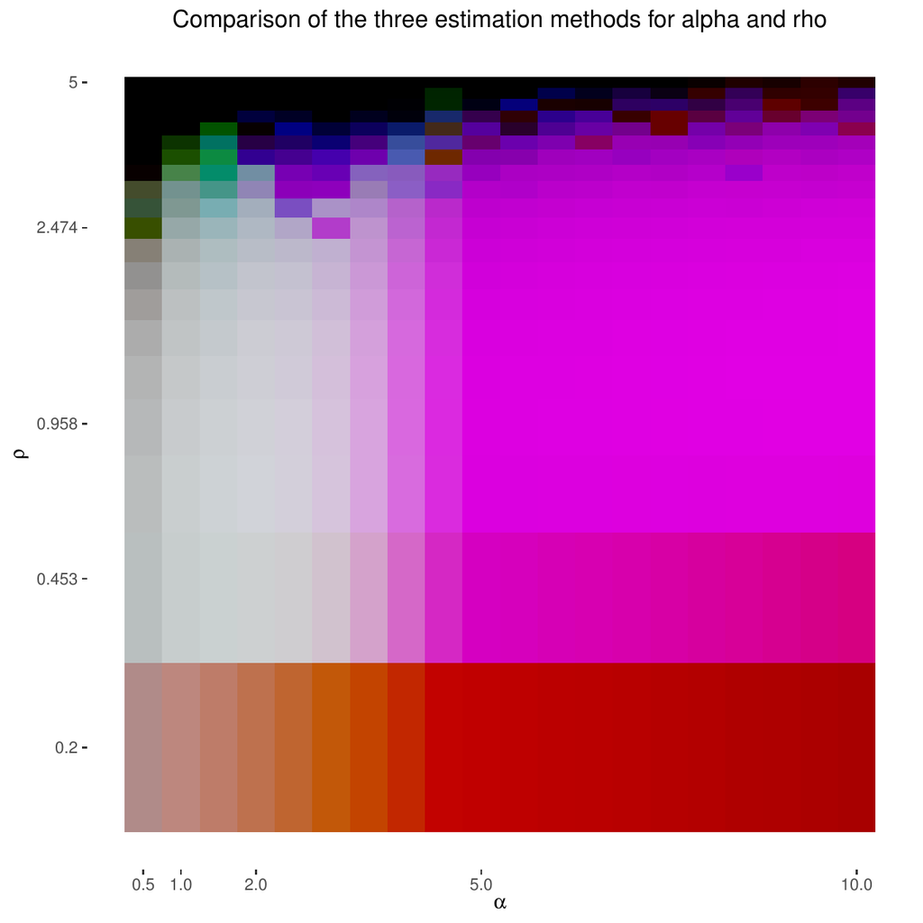

Figure 1: **Map of usage of the estimation methods under $\mathbf{LD}$ model.** The map compares the three methods according to their relative MSE (8). For each of 400 couples of parameters $\alpha=0.5\,\dots\,10$ (x-axis) and $\rho=0.2\,\dots\,5$ (y-axis, $\log_5$-scale), $10^4$ samples of size 100 of the $LD(\alpha,\rho,0,1)$ distribution were simulated. The estimates of $(\alpha,\rho)$ were calculated with the three methods. Each method is represented by a color: red for GF, green for P0, blue for ML.

The map can be roughly divided into four distinct parts:

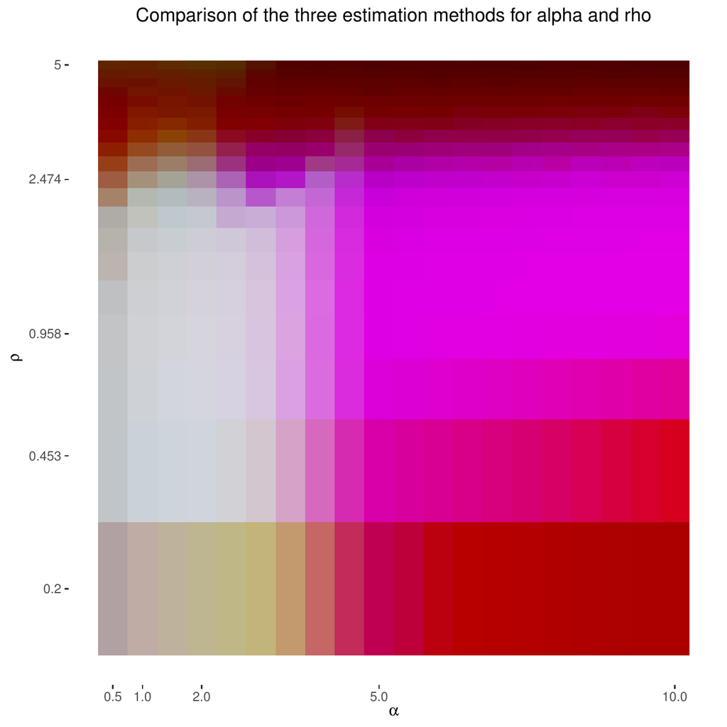

Figure 2: **Map of usage of the estimation methods under $\mathbf{H}$ model.** The map compares the three methods according to their relative MSE (8). For each of 400 couples of parameters $\alpha=0.5\,\dots\,10$ (x-axis) and $\rho=0.2\,\dots\,5$ (y-axis, $\log_5$-scale), $10^4$ samples of size 100 of the $H(\alpha,\rho,0,1)$ distribution were simulated. The estimates of $(\alpha,\rho)$ were calculated with the three methods. Each method is represented by a color: red for GF, green for P0, blue for ML.

Figure 2 is quite similar to Figure 1. There are still two remarkable differences:

- For $\rho$ small and $m\leqslant2$, the three methods seem to be more equivalent under $H$ model than under $LD$ model.
- For $\rho$ large, GF method seems to provide better estimates under $H$ model than under $LD$ model.

### 3.3 Bias evidence

If the model used for the estimation does not correspond to the theoretical model, the estimates can be biased. Four different sources of bias are considered:

1. the final counts are random in the data, constant for the estimation model;
2. cell deaths occur in the data, not in the estimation model;
3. the lifetime distribution is different in the data and the estimation model;
4. the plating process is less than 100% efficient.

In each case, simulation experiments have been made along the following lines:

1. draw $10^4$ samples of size 100, under one model;
2. for each sample, compute estimates using another model and the true one if available;
3. compare the empirical distributions of $\hat{\theta}/\theta$, where $\hat{\theta}$ is estimator and $\theta$ the true value.

For each figure, red lines mark unit, blue lines mark relative biases of 0.9 and 1.1. According to Figures 1 and 2, the GF method is at least equivalent in terms of the relative MSE (8) to the ML and P0 methods. Moreover, it is also the best in terms of computational time. Therefore, the bias evidences will be mainly illustrated with GF method.

##### Fluctuation of final counts:

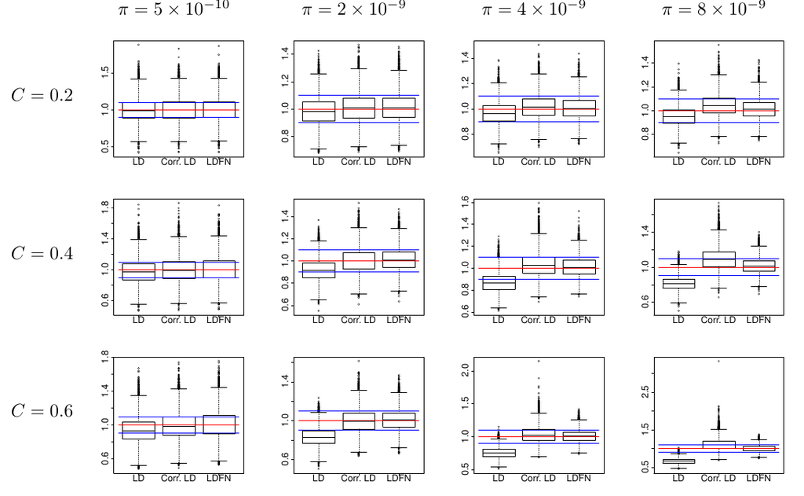

Figure 3: **ML estimates of $\pi$ ignoring fluctuations of final numbers or not.** Red horizontal lines mark unit. Blue horizontal lines mark relative bias of 0.9 and 1.1. For each of the 12 sets of parameters $\pi=(0.5/\mu,2/\mu,4/\mu,8/\mu)$ (columns), and $C=(0.2,0.4,0.6)$ (rows), $10^4$ samples of size 100 of the $LDFN(\pi,\rho,0,1,K)$ distribution were simulated, with $\rho=1$ and $K$ being the log-normal distribution adjusted to mean $\mu=10^9$ and coefficient of variation $C$. The ML estimates of $\pi$ and $\rho$ were calculated under model $LD$ or $LDFN$. Each boxplot represents the distribution of the $10^4$ ratio $\hat{\pi}/\pi$ obtained with $LD$ model with $C=0$ (left), $LD$ model with bias reduction (center), $LDFN$ model (right).

##### Cell deaths:

The PGFs (1), (4) and (2) depend on $\delta$. Ignoring cell deaths involves a negative bias on the estimate of $\alpha$. Assuming the exact value is known, this bias is removed. Figure 4 shows the influence of the death parameter $\delta$ on the GF estimate of $\alpha$. The estimates are calculated with two different approaches:

1. computing GF estimates of $\alpha$ with $\delta=0$ (left boxplots);
2. computing GF estimates of $\alpha$ with a theoretical value of $\delta$ (right boxplots).

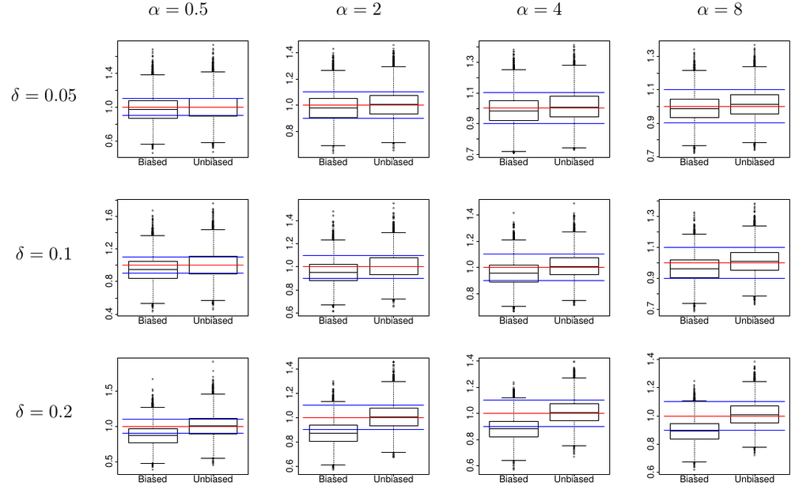

Figure 4: **GF estimates of $\alpha$ ignoring cell deaths or not.** Red horizontal lines mark unit. Blue horizontal lines mark relative bias of 0.9 and 1.1. For each of the 12 sets of parameters $\alpha=(0.5,2,4,8)$ (columns), and $\delta=(0.05,0.1,0.2)$ (rows), $10^4$ samples of size 100 of the $LD(\alpha,\rho,\delta,1)$ distribution were simulated, with $\rho=1$. The GF estimates of $\alpha$ and $\rho$ were calculated under $LD$ model. Each boxplot represents the distribution of the $10^4$ ratio $\hat{\alpha}/\alpha$ of the estimates obtained without taking account of cells death (left) and with the theoretical value of $\delta$ (right).

##### Lifetime distribution:

As mentioned earlier, the PGF $h$ is explicit only for the $LD$ and $H$ distributions, i.e. when lifetimes are either exponential or constant. This is not the case in practice. If another lifetime distribution is used to simulate the data, and either $LD$ or $H$ are used to estimate the parameters, a bias will be induced on $\alpha$ and $\rho$. Figure 5 illustrates these observations. It shows the influence of the lifetime distribution on the GF estimates of $\alpha$ and $\rho$. The samples are drawn assuming the lifetimes are log-normally distributed. The estimates of $\alpha$ and $\rho$ are calculated under $LD$ (left boxplots) and $H$ models (right boxplots).

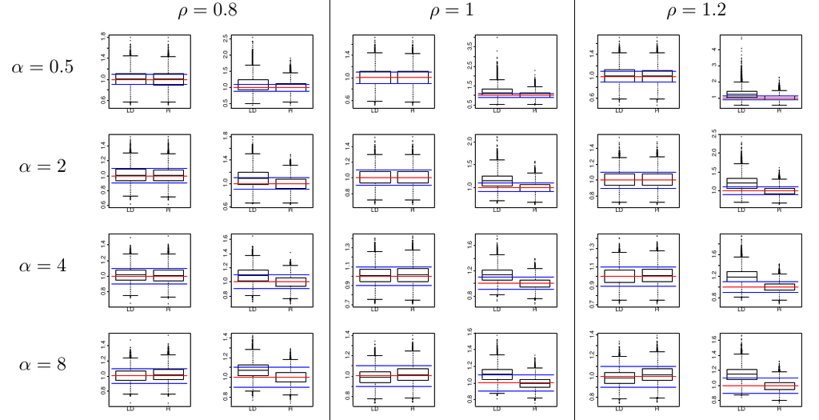

Figure 5: **GF estimates of $\alpha$ and $\rho$ under $LD$ and $H$ models on data drawn with $MM$ model.** Red horizontal lines mark unit. Blue horizontal lines mark relative bias of 0.9 and 1.1. For each of the 12 sets of parameters $\alpha=(0.5,2,4,8)$ (rows), and $\rho=(0.8,1,1.2)$ (columns), $10^4$ samples of size 100 of the $MM(\alpha,\rho,0,1,G)$ distribution were simulated, $G$ being the log-normal distribution adjusted on Kelly and Rahn’s data (Kelly and Rahn 1932). The GF estimates of $\alpha$ and $\rho$ were calculated with the two distributions $LD(\alpha,\rho,0,1)$ and $H(\alpha,\rho,0,1)$. For each couple $(\alpha,\rho)$, the two first boxplots represent the distribution of the $10^4$ ratio $\hat{\alpha}/\alpha$ obtained by the $LD$ model (left) and the $H$ model (right); the two last boxplots represent the distribution of the $10^4$ ratio $\hat{\rho}/\rho$ obtained by the $LD$ model (left) and the $H$ model (right)

##### Plating efficiency:

1. computing GF estimates with $\zeta=1$ (left boxplots) ;
2. applying the correction of Stewart et al. (1990, eq. (41)) to GF estimates (center boxplots);
3. computing GF estimates with known value of $\zeta$ (right boxplots).

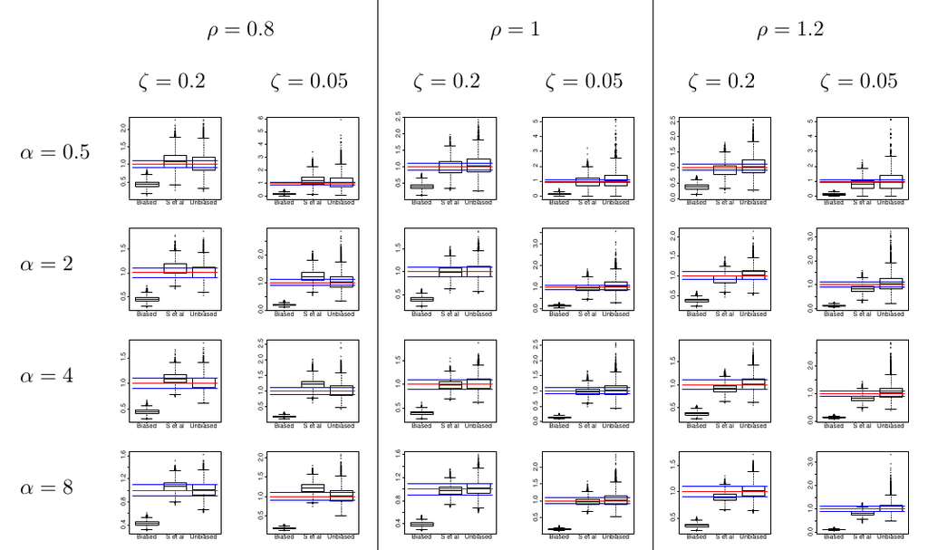

Figure 6: **GF estimates of $\alpha$ ignoring plating efficiency or not.** Red horizontal lines mark unit. Blue horizontal lines mark relative bias of 0.9 and 1.1. For each of the 12 sets of parameters $\alpha=(0.5,2,4,8)$ (rows), and $\rho=(0.8,1,1.2)$ (columns), $10^4$ samples of size 100 of the $LD(\alpha,\rho,0,\zeta)$ distribution were simulated, with $\zeta=0.2$ and $\zeta=0.05$. The GF estimates of $\alpha$ and $\rho$ were calculated under $LD$ model. Each boxplot represents the distribution of the $10^4$ ratio $\hat{\alpha}/\alpha$ obtained with $\zeta=1$ (left), using the Stewart et al. (1990) correction (center), and with the true value of $\zeta$ (right).

The visual results illustrate first the fact that the correction of Stewart et al. (1990) should not be used when $\rho\neq1$: the induced bias on $\alpha$ is negative when $\rho>1$, positive when $\rho<1$. However, the variance of the estimates obtained with these rectification is smaller than that of the estimates calculated with GF method.

## 4 Implementation details

The available functions are described here; more details are given in the manual. The behavior of inference functions for inputs which are out of practical limitations is described. Some details about the *Rcpp* implementation are also provided.

### 4.1 User interface

The function `flan.test` is a wrapper function of `mutestim`. It will ouput the same errors or warning messages if its inputs do not respect the practical limitations.

### 4.2 Implementation

Since most functions involve loops that are more expensive in R than in C, *flan* has been implemented with *Rcpp* modules. This paradigm provides an easy way to expose C++ functions and classes to R. There are four main classes in the C++ implementation:

- `FLAN_Sim`: random generation for $MM$ and $MMFN$ distributions. One of its members is a variable of the following type;
- `FLAN_SimClone`: random generation for clone size distribution according to the lifetimes distribution;
- `FLAN_MutationModel`: computation of the descriptive functions (probabilities, PGF,...) for $LD$ and $H$ distributions. One of its members is a variable of the following type;
- `FLAN_Clone`: computation of the descriptive functions for clone size distribution according to the lifetimes distribution.

The *Rcpp* interface enables also to import into the C++ code any R function. In particular, it is interesting to import the R functions which are already implemented in C. Thus no external C/C++ library is required. The installation remains basic, and the size of the installed package is reduced. For example, the computations of $LD$ distributions involve numeric integrations. The C libraries **integration** and **alglib** compute integrals with an accuracy close to machine precision. We could use those libraries but the R function `integrate` is actually implemented in C. The R function can then be directly called into the C++ code. However, such imports increase the computational time and memory consumption. This is thus unsatisfactory. Another solution uses the package [*RcppGSL*](https://CRAN.R-project.org/package=RcppGSL) (Eddelbuettel 2013 11), which creates an interface between *Rcpp* and the C library gsl. Several integration methods are thus available. Since it only requires that gsl is correctly installed, this solution is a good compromise between easy setup and computational cost.

Computing the probabilities for the $H$ distribution with $\delta>0$ involves squaring high degree polynomials. Such polynomials are easily treated by the package [*polynom*](https://CRAN.R-project.org/package=polynom). However its implementation raises memory issues, because of the degree of the polynomials involved. A more efficient way is to use the Fast Fourier Transform. It is provided by the C library fftw3, which can raise some installation issues. The R function `fft` could be directly called into the C++ code. For the same reasons as for the `integrate` function, it is more adequate to use the package [*RcppArmadillo*](https://CRAN.R-project.org/package=RcppArmadillo) (Eddelbuettel (2013 10) ; Eddelbuettel and Sanderson (2014)). This package links *Rcpp* to the C++ library armadillo, which is dedicated to linear algebra. In particular, it includes a performant Fast Fourier Transform.

Finally, likelihood optimizations in the ML and P0 methods are done with a bounded BFGS optimizer. The package [*lbfgsb3*](https://CRAN.R-project.org/package=lbfgsb3) provides the eponymous function which is implemented in Fortran. It is much faster than the basic R function `optim`.

## 5 Examples of usage

Some examples on the real data included in *flan* are provided.

Practical limitations, influence of bias sources and comparison of the estimation methods in terms of computational time are illustrated. Consider first the eleventh sample of mutant counts of the `werhoff` data (Werngren and Hoffner 2003):

```r
werhoff$samples$W11$mc
```

```
##  [1] 0 0 1 1 1 1 1 1 1 2 2 2 2 2 2 2 2 3 3 4 4 4 4 5 5
```

This sample does not contain any jackpot, then the theoretical fitness in a mutation model, should be very large. If the GF method is used, it will output a warning message and set the fitness at $\rho=1$, as customarily done in the litterature (Foster 2006):

```r
W <- werhoff$samples$W11$mc

# Compute GF estimates of mutations number and fitness}
mutestim(mc = W, method = "GF")

## Warning in mutestim(mc = W, method = "GF"): Impossible to estimate
## 'fitness' with 'GF'-method: 'fitness' is set to default value 1 and
## only mutations number is estimated.

## $mutations
## [1] 0.8792917
##
## $sd.mutations
## [1] 0.260549
##
## $fitness
## [1] 1
##
## $sd.fitness
## [1] 0
```

Notice that Table 1 of (Werngren and Hoffner 2003) shows mutants counts and mean final numbers of cells for 1 mL of solution. However, the total volume of the culture is 5 mL. In other words, a plating efficiency of 20% has been applied. The fact is the fitness parameter can not be estimated, even taking into account the plating efficiency:

```r
# Volume of each sample: 1 mL
# Total volume of each culture: 5 mL
# i.e. plating efficiency of 0.2
pef <- 0.2

# Compute GF estimates of mutation probability and fitness
# taking into account the plating efficiency
mutestim(mc = W, plateff = pef, method = "GF")

## Warning in mutestim(mc = W, plateff = pef, method = "GF"): Impossible to estimate 'fitness' with
## 'GF'-method: 'fitness' is set to default value 1 and only mutations number is estimated.

## $mutations
## [1] 2.804244
##
## $sd.mutations
## [1] 0.74011
##
## $fitness
## [1] 1
##
## $sd.fitness
## [1] 0
```

Using the P0 method is a way to realize that setting $\rho=1$ by default can be misleading. Since this method does not depend on the lifetime distribution, the estimate of $\alpha$ will not depend on the value of $\rho$.

```r
# Compute P0 estimate of mutations number
mutestim(mc = W, fitness = 1, method = "P0")

## $mutations
## [1] 2.525729
##
## $sd.mutations
## [1] 0.678233
```

The P0 estimate of $\alpha$ is very different from the GF estimate (when $\zeta=1$). Consider now the sample of David (1970, Tab. 2), which includes rifampin-resistant bacteria counts.

```r
david$D11

## $mc
##  [1] 4 0 1 0 1 0 0 0 0 0
##
## $fn
##  [1] 1.3e+09 9.2e+08 1.3e+09 2.5e+09 1.3e+09 1.6e+09 1.3e+09 2.5e+09
##  [9] 2.5e+09 2.0e+09
```

Since the $4$ value can be seen as a jackpot, the GF method can be used to estimate $\alpha$ and $\rho$. Now let us compute the ML estimates of $\pi$ and $\rho$ taking into account or not of the final counts, under the $LD$ model.

```r
D <- david$D11
Dmfn <- mean(D$fn)

# Compute ML estimates and confidence intervals of mutation probability and
# fitness with empirical mean and null coefficient of variation
ft <- flan.test(mc = D$mc, mfn = Dmfn)
ft$estimate

## mutation probability              fitness
##         2.067641e-10         2.214676e+00

ft$conf.int

##      mutation probability  fitness
## bInf         0.000000e+00 0.000000
## bSup         4.423916e-10 8.109577
## attr(,"conf.level")
## [1] 0.95

# Compute ML estimates and confidence intervals of mutation probability and
# fitness with empirical mean and empirical coefficient of variation
ft <- flan.test(mc = D$mc, mfn = Dmfn, cvfn = sd(D$fn)/Dmfn)
ft$estimate

## mutation probability              fitness
##         2.092720e-10         2.214676e+00

ft$conf.int

##      mutation probability  fitness
## bInf         0.000000e+00 0.000000
## bSup         4.506155e-10 8.109577
## attr(,"conf.level")
## [1] 0.95

# Compute ML estimates and confidence intervals of mutation probability and
# fitness with couples (mc,fn)
ft <- flan.test(mc = D$mc, fn = D$fn)
ft$estimate

## mutation probability              fitness
##         1.977135e-10         2.048984e+00

ft$conf.int

##      mutation probability  fitness
## bInf         0.000000e+00 0.000000
## bSup         4.078591e-10 7.127426
## attr(,"conf.level")
## [1] 0.95
```

Table 1: **ML estimates of $\mathbf{\pi}$ and $\mathbf\rho$ of data set from (David 1970 Tab. 2) ignoring fluctuations of final numbers or not.** Each row shows the ML estimates of $\pi$ and $\rho$ and their 95% confidence intervals, deducing from $LD$ model with $C=0$ (first row), $C=\overline{C}$ (second row), and directly with $LDFN$ model (third row).

[output not shown]

Consider finally the data from Boe et al. (1994, Tab. 4). The author studied mutations of *Escherichia coli* from sensitivity to nalidixic acid resistance. 23 samples of resistant bacteria counts are provided. As in the original paper, the 23 samples are concatenated as one. The three estimation methods are compared in terms of computational time on the resulting sample of size 1104. The package **microbenchmark** is used, evaluating $10^4$ times each method on the sample. The methods are compared when only $\alpha$ is estimated ($\rho=1$), and when the couple $(\alpha{,}\rho)$ is estimated. In both cases the estimates are computed under the model $LD$ with $\delta=0$ and $\zeta=1$.

```r
B <- unlist(boeal)       # Concatenation of the 23 samples
require(microbenchmark)

# Comparing the methods in terms of computational performance
# (mutations number only)
microbenchmark(P0 = mutestim(mc = B, fitness = 1, method = "P0"),
               GF = mutestim(mc = B, fitness = 1, method = "GF"),
               ML = mutestim(mc = B, fitness = 1, method = "ML"),
               unit = "ms", times = 1e4)

## Unit: milliseconds
##  expr       min        lq      mean    median        uq       max neval
##    P0  0.063696  0.0800720  0.09701435  0.0899955  0.0986275  2.149537 10000
##    GF 0.327989  0.3694555  0.41309310  0.3850380  0.4035050 26.774004 10000
##    ML 8.381844 10.5333670 12.23137063 10.9118690 11.3860045 43.592177 10000

# Comparing the methods in terms of computational performance}
microbenchmark(P0 = mutestim(mc = B, method = "P0"),
               GF = mutestim(mc = B, method = "GF"),
               ML = mutestim(mc = B, method = "ML"),
               unit = "ms", times = 1e4)

## Unit: milliseconds
##  expr       min        lq      mean    median        uq       max neval
##    P0  8.451605 11.004419 12.832827 11.848562 13.082066  43.00397 10000
##    GF  2.274944  2.419663  2.688851  2.481529  2.549597  33.19333 10000
##    ML 73.704656 79.581238 83.841150 81.802464 84.323398 120.65768 10000
```

The results are shown on Figure 7, as boxplots of timing distributions. Times are in milliseconds and plotted on log-scale.

Estimates of *α* setting *ρ* = 1

Estimates of the couple (*α*,*ρ*)

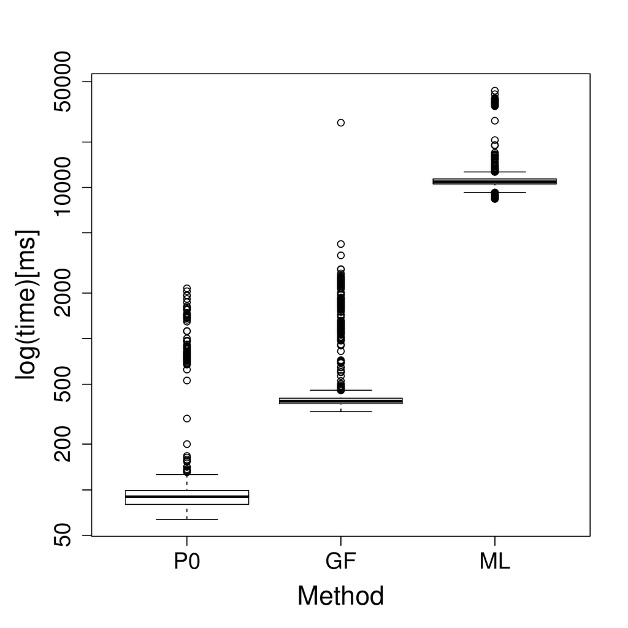

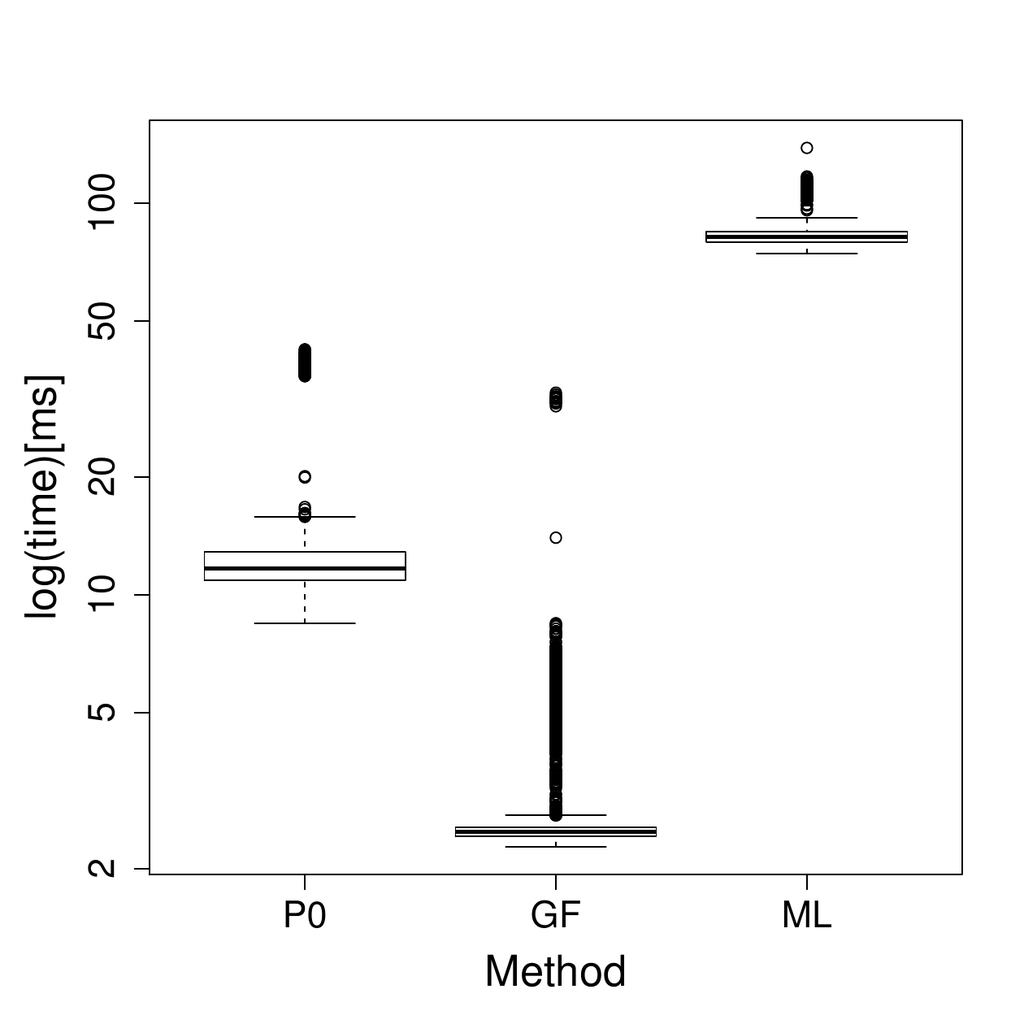

Figure 7: **Computational time of the three methods on data from Boe et al. (1994, Tab. 4).** Data consist in the 23 samples of `boeal` concatenated as one. For each method, the estimates of *α* setting *ρ* = 1 (left boxplots) or of *α* and *ρ* (right boxplots) have been computed under model *L**D*. The timings have been returned with **microbenchmark**, evaluating 10<sup>4</sup> times each method. Times are in milliseconds and plotted on log-scale.

As mentioned earlier, the ML method is the slowest. The GF method seems to be quite faster than the P0 method. However, the estimates of $\rho$ of the P0 method is calculated maximizing the likelihood. This step is more costly in term of computational time. If only $\alpha$ has to be estimated, the P0 method is faster than the GF method.

### 5.1 CRAN packages used

flan, Rcpp, ggplot2, RcppGSL, polynom, RcppArmadillo, lbfgsb3

### 5.2 CRAN Task Views implied by cited packages

ChemPhys, HighPerformanceComputing, NetworkAnalysis, NumericalMathematics, Phylogenetics, Spatial, TeachingStatistics

W. P. Angerer. A note on the evaluation of fluctuation experiments. *Mutation Research*, 479: 207–224, 2001a. URL https://doi.org/10.1016/S0027-5107(01)00203-2.

W. P. Angerer. An explicit representation of the Luria-Delbrück distribution. *J. Math. Biol.*, 42(2): 145–174, 2001b. URL https://doi.org/10.1007/s002850000053.

P. Armitage. The statistical theory of bacterial populations subject to mutation. *J. R. Statist. Soc. B*, 14: 1–40, 1952. URL http://www.jstor.org/stable/2984083.

K. B. Athreya and P. E. Ney. *Branching processes.* Berlin Heidelberg: Springer-Verlag, 1972. URL https://doi.org/10.1007/978-3-642-65371-1.

M. S. Bartlett. *An introduction to stochastic processes, with special reference to methods and applications.* 3rd ed Cambridge University Press, 1978.

R. Bellman and T. Harris. On age-dependent binary branching processes. *Ann. Math.*, 55(2): 280–295, 1952. URL https://www.jstor.org/stable/1969779.

L. Boe, T. Tolker-Nielsen, K. M. Eegholm, H. Spliid and A. Vrang. Fluctuation analysis of mutations to nalidixic acid resistance in *escherichia coli*. *J. Bacteriol.*, 176(10): 2781–2787, 1994. URL https://doi.org/10.1128/jb.176.10.2781-2787.

R. Breunig. An almost unbiased estimator of the coefficient of variation. *Econ. Lett.*, 70(1): 15–19, 2001. URL https://doi.org/10.1016/S0165-1765(00)00351-7.

H. L. David. Probability distribution of drug-resistant mutants in unselected populations of *mycobacterium tuberculosis*. *Appl. Microbiol.*, 20(5): 810–814, 1970. URL https://www.ncbi.nlm.nih.gov/pmc/articles/PMC377053/.

A. Dewanji, E. G. Luebeck and S. H. Moolgavkar. A generalized Luria-Delbrück model. *Math. Biosci.*, 197(2): 140–152, 2005. URL https://doi.org/10.1016/j.mbs.2005.07.003.

D. Eddelbuettel. *Seamless r and c++ integration with rcpp.* New York: Springer-Verlag, 2013. URL https://doi.org/10.1007/978-1-4614-6868-4.

D. Eddelbuettel and C. Sanderson. RcppArmadillo: Accelerating R with high-performance C++ linear algebra. *Comput. Stat. Data An.*, 70: 1054–1063, 2014. URL https://doi.org/10.1016/j.csda.2013.02.005.

P. Embrechts and J. Hawkes. A limit theorem for the tails of discrete infinitely divisible laws with applications to fluctuation theory. *J. Austral. Math. Soc. Series A*, 32: 412–422, 1982. URL https://doi.org/10.1017/S1446788700024976.

P. L. Foster. Methods for determining spontaneous mutation rates. *Method. Enzymol.*, 409: 195–213, 2006. URL https://doi.org/10.1016/S0076-6879(05)09012-9.

A. Gillet-Markowska, G. Louvel and G. Fisher. Bz-rates: A web-tool to estimate mutation rates from fluctuation analysis. *G3*, 5(11): 2323–2327, 2015. URL https://doi.org/10.1534/g3.115.019836.

B. M. Hall, C. X. Ma, P. Liang and K. K. Singh. Fluctuation AnaLysis CalculatOR: A web tool for the determination of mutation rate using Luria–Delbrück fluctuation analysis. *Bioinformatics*, 25(12): 1564–1565, 2009. URL https://doi.org/10.1093/bioinformatics/btp253.

A. Hamon and B. Ycart. Statistics for the Luria-Delbrück distribution. *Elect. J. Statist.*, 6: 1251–1272, 2012. URL https://doi.org/10.1214/12-EJS711.

C. D. Kelly and O. Rahn. The growth rate of individual bacterial cells. *J. Bacteriol.*, 23(2): 147–153, 1932. URL http://europepmc.org/articles/PMC533308.

N. L. Komarova, L. Wu and P. Baldi. The fixed-size Luria-Delbrück model with a nonzero death rate. *Math. Biosci.*, 210(1): 253–290, 2007. URL https://doi.org/10.1016/j.mbs.2007.04.007.

D. E. Lea and C. A. Coulson. The distribution of the number of mutants in bacterial populations. *Journal of Genetics*, 49(3): 264–285, 1949. URL https://doi.org/10.1007/BF02986080.

S. E. Luria and M. Delbrück. Mutations of bacteria from virus sensitivity to virus resistance. *Genetics*, 28(6): 491–511, 1943. URL https://www.genetics.org/content/28/6/491.

W. T. Ma, G. v. H. Sandri and S. Sarkar. Analysis of the Luria-Delbrück distribution using discrete convolution powers. *J. Appl. Probab.*, 29(2): 255–267, 1992. URL https://doi.org/10.1017/S0021900200043023.

B. Rémillard and R. Theodorescu. Inference based on the empirical probability generating function for mixtures of Poisson distributions. *Statist. Decisions*, 18: 349–366, 2000. URL https://doi.org/10.1524/strm.2000.18.4.349.

S. Sarkar. Haldane’s solution of the Luria-Delbrück distribution. *Genetics*, 127: 257–261, 1991.

F. M. Stewart. Fluctuation analysis: The effect of plating efficiency. *Genetica*, 84(1): 51–55, 1991. URL https://doi.org/10.1007/BF00123984.

F. M. Stewart, D. M. Gordon and B. R. Levin. Fluctuation analysis: The probability distribution of the number of mutants under different conditions. *Genetics*, 124(1): 175–185, 1990. URL https://www.genetics.org/content/124/1/175.

J. Werngren and S. E. Hoffner. Drug susceptible *mycobacterium tuberculosis beijing* genotype does not develop motation-conferred resistance to Rifampin at an elevated rate. *J. Clin. Microbiol.*, 41(4): 1520–1524, 2003. URL https://doi.org/10.1128/jcm.41.4.1520-1524.2003.

R. Wilcox. *Introduction to robust estimation and hypothesis testing.* 3rd ed Amsterdam: Elsevier, 2012. URL https://doi.org/10.1016/C2010-0-67044-1.

B. Ycart. Fluctuation analysis with cell deaths. *J. Appl. Probab. Statist*, 9(1): 13–29, 2014. URL https://arxiv.org/abs/1207.4375.

B. Ycart. Fluctuation analysis: Can estimates be trusted? *PLoS One*, 8(12): 1–12, 2013. URL https://doi.org/10.1371/journal.pone.0080958.

B. Ycart and N. Veziris. Unbiased estimates of mutation rates under fluctuating final counts. *PLoS One*, 9(7): 1–10, 2014. URL https://doi.org/10.1371/journal.pone.0101434.

Q. Zheng. New algorithms for Luria-Delbrück fluctuation analysis. *Math. Biosci.*, 196(2): 198–214, 2005. URL https://doi.org/10.1016/j.mbs.2005.03.011.

Q. Zheng. Statistical and algorithmic methods for fluctuation analysis with SALVADOR as an implementation. *Math. Biosci.*, 176(2): 237–252, 2002. URL https://doi.org/10.1016/S0025-5564(02)00087-1.